# Mississippi Silverside data from Delta Juvenile Fish Monitoring Program

Brian Mahardja

11/3/2021

## Delta Juvenile Fish Monitoring Program

Interagency Ecological Program (IEP), R. McKenzie, J. Speegle, A. Nanninga, J.R. Cook, J. Hagen, and B. Mahardja. 2021. Interagency Ecological Program: Over four decades of juvenile fish monitoring data from the San Francisco Estuary, collected by the Delta Juvenile Fish Monitoring Program, 1976-2020 ver 7. Environmental Data Initiative. https://doi.org/10.6073/pasta/3d2b756ae45f43ddb895dc118f28b314

The United States Fish and Wildlife Service Delta Juvenile Fish Monitoring Program (DJFMP) has monitored juvenile Chinook Salmon Oncorhynchus tshawytscha and other fish species within the San Francisco Estuary (Estuary) since 1976 using a combination of surface trawls and beach seines. Since 2000, three trawl sites and 58 beach seine sites have been sampled weekly or biweekly within the Estuary and lower Sacramento and San Joaquin Rivers. As part of the Interagency Ecological Program (IEP) that manages the Estuary, the DJFMP has tracked the relative abundance and distribution of naturally and hatchery produced juvenile Chinook Salmon of all races as they outmigrate through the Sacramento-San Joaquin Delta for over four decades. The data that DJFMP collected has been used not only to help inform the management of Chinook Salmon, but also to monitor the status of native species of interest such as the previously listed Sacramento Splittail Pogonichthys macrolepidotus and invasive species such as Mississippi Silverside Menidia beryllina and Largemouth Bass Micropterus salmoides. For more information: https://www.fws.gov/lodi/juvenile_fish_monitoring_program/jfmp_index.htm

## Load data and show sampling effort

Load data using `deltafish` package and show map of beach seine stations.

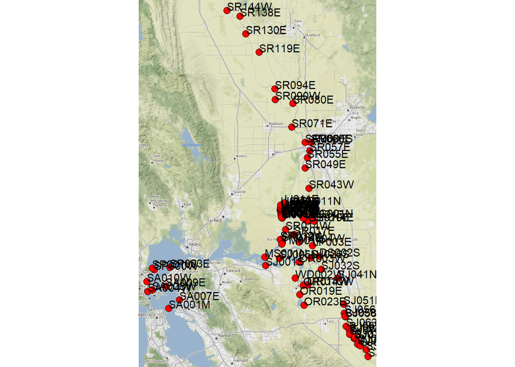

## Subset stations

A lot of stations outside of our study region and many of those are not sampled consistently since the 1970s (based on experience).

Will subset to just the stations found in my paper:

Mahardja B, Farruggia MJ, Schreier B, Sommer T. 2017. Evidence of a shift in the littoral fish community of the Sacramento-San Joaquin Delta. PLoS One. 12(1):e0170683. https://journals.plos.org/plosone/article?id=10.1371/journal.pone.0170683

See map:

```r
long_term_stations<- c("DS002S", "GS010E", "LP003E","MK004W", "MR010W", "MS001N","MS001A","OR003W","OR014W","SF014E","SJ001S", "SJ005N", "SJ032S","SJ041N","SJ051E", "SJ056E", "SJ058W", "SJ058E","SR012E","SR012W","SR014W",  "SR017E", "SR024E", "SR043W", "SR049E", "SS011N","TM001N", "WD002W","WD002E","XC001N" )
long_term_stations
```

```
##  [1] "DS002S" "GS010E" "LP003E" "MK004W" "MR010W" "MS001N" "MS001A" "OR003W"
##  [9] "OR014W" "SF014E" "SJ001S" "SJ005N" "SJ032S" "SJ041N" "SJ051E" "SJ056E"
## [17] "SJ058W" "SJ058E" "SR012E" "SR012W" "SR014W" "SR017E" "SR024E" "SR043W"
## [25] "SR049E" "SS011N" "TM001N" "WD002W" "WD002E" "XC001N"
```

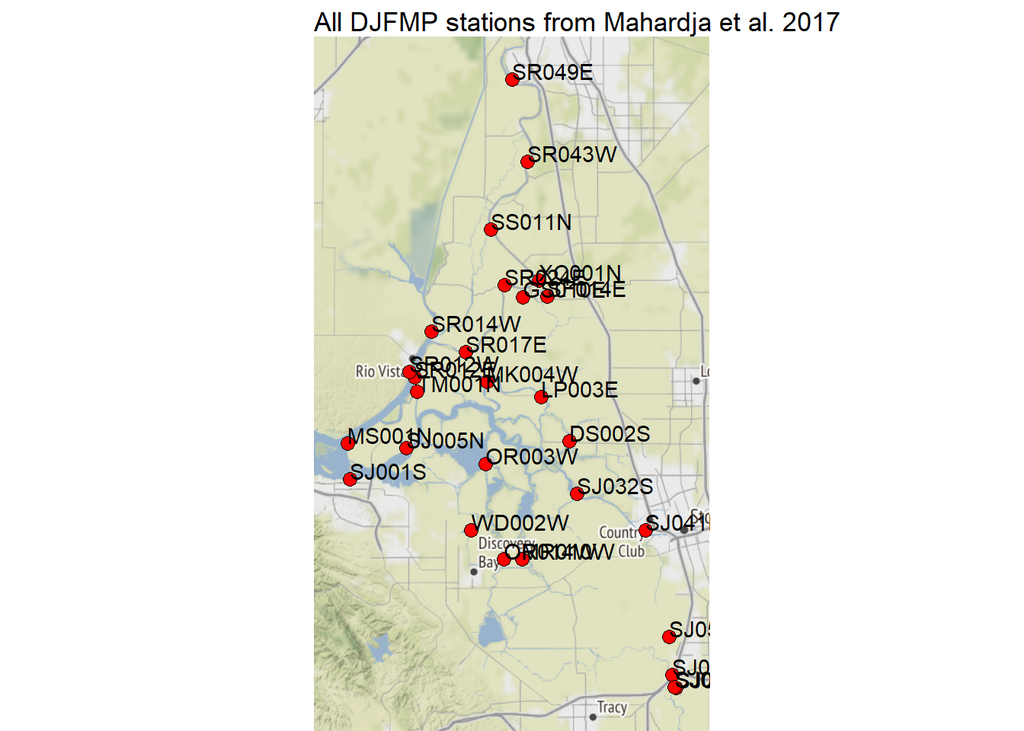

```r
DJFMP_Coords_study_stations<-DJFMP_Coords %>% filter(Station %in% long_term_stations)

map <- create_station_map(DJFMP_Coords_study_stations)+ labs(title="All DJFMP stations from Mahardja et al. 2017")
map
```

Check sampling effort for the subset of stations:

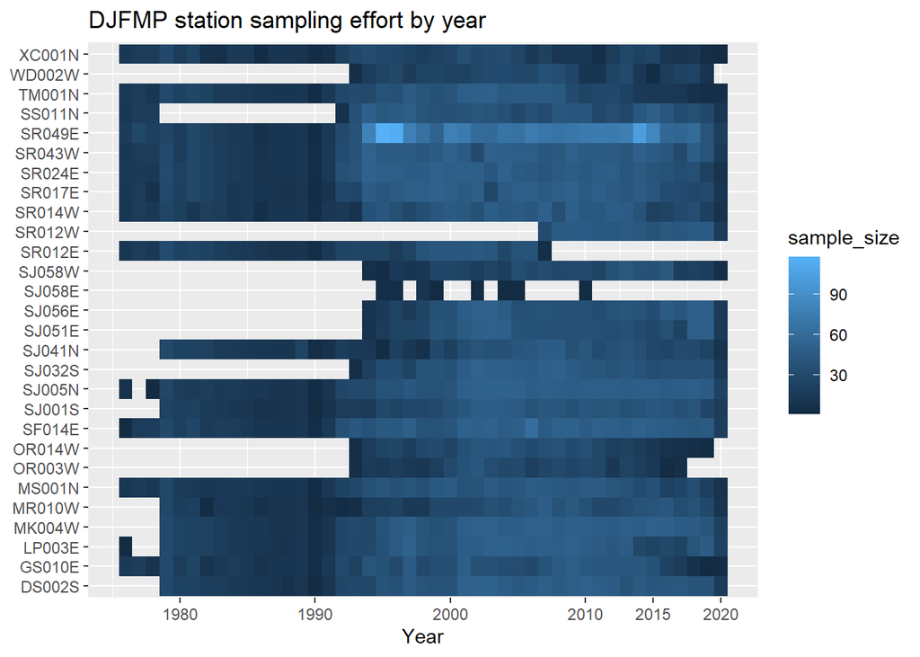

```r
DJFMP_Coords_study_stations_subset_annual <-DJFMP_Coords_study_stations %>%
  filter(Station %in% c("XC001N","TM001N","SR049E","SR043W","SR024E","SR017E","SR014W","SR012E","SR012W","SJ041N","SJ005N","SJ001S","SF014E","MS001N","MR010W","MK004W","LP003E","GS010E","DS002S"))

DJFMP_Coords_study_stations_subset_annual
```

```
## # A tibble: 19 x 3
##    Station Latitude Longitude
##    <chr>      <dbl>     <dbl>
##  1 DS002S      38.1     -121.
##  2 GS010E      38.2     -122.
##  3 LP003E      38.1     -122.
##  4 MK004W      38.1     -122.
##  5 MR010W      37.9     -122.
##  6 MS001N      38.1     -122.
##  7 SF014E      38.2     -121.
##  8 SJ001S      38.0     -122.
##  9 SJ005N      38.1     -122.
## 10 SJ041N      38.0     -121.
## 11 SR012E      38.1     -122.
## 12 SR012W      38.1     -122.
## 13 SR014W      38.2     -122.
## 14 SR017E      38.2     -122.
## 15 SR024E      38.2     -122.
## 16 SR043W      38.4     -122.
## 17 SR049E      38.5     -122.
## 18 TM001N      38.1     -122.
## 19 XC001N      38.2     -122.
```

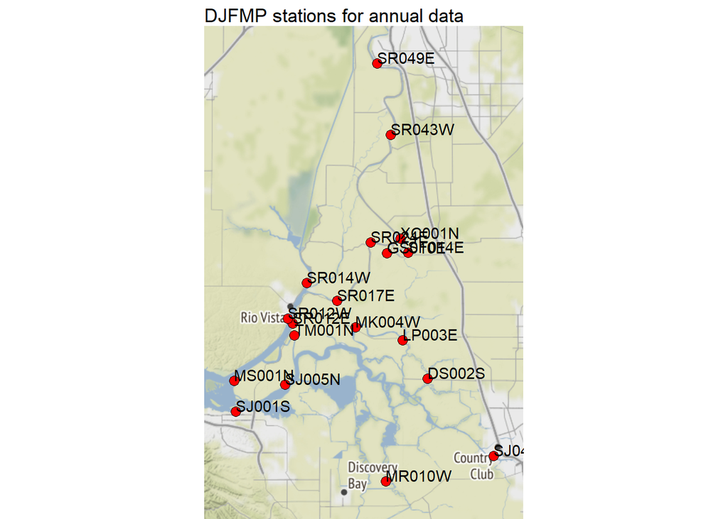

```r
map <- create_station_map(DJFMP_Coords_study_stations_subset_annual) + labs(title="DJFMP stations for annual data")
map
```

## Finalize list of stations for annual data

Show sampling effort by month and year for the final list of stations:

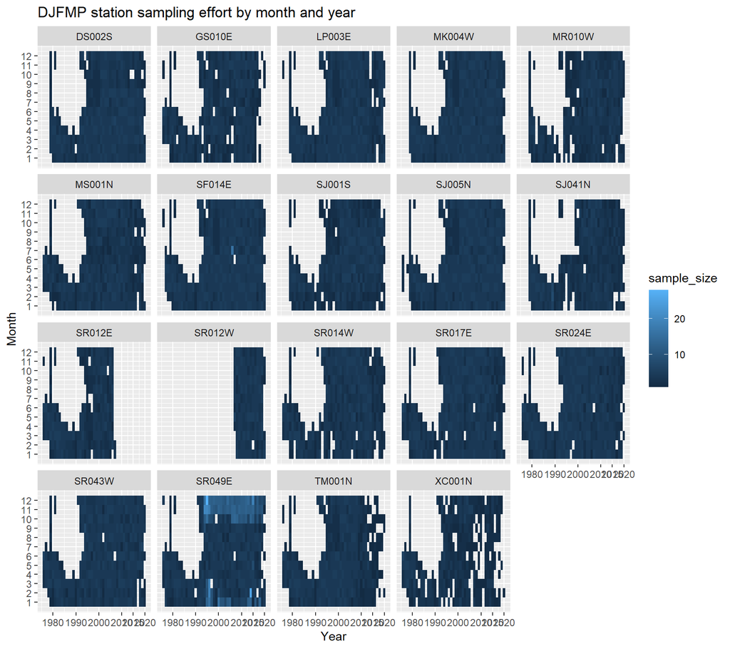

Lots of months were not sampled in the earlier years (pre-1990s). Sampling timeframe moved from the 1970s to 1990s somewhat. Will use just months from January to May to improve consistency somewhat. WARNING: Note that January to May are when Mississippi Silverside catch is declining (see Mahardja et al. 2016). I didn’t include June because two cohorts comingle often in June.

Mahardja B, Conrad JL, Lusher L, Schreier B. 2016. Abundance Trends, Distribution, and Habitat Associations of the Invasive Mississippi Silverside. San Fr Estuary Watershed Sci. 14(1). doi:10.15447/sfews.2016v14iss1art2. https://escholarship.org/uc/item/55f0s462.

## Final data processing for annual data

- Export stations to data_stations folder
- Join SR012E and SR012W together
- Add length-weight conversion to get biomass
- Use just January-May
- Filtered to region boundaries as defined by Denise
- Write csv to annual averages folder

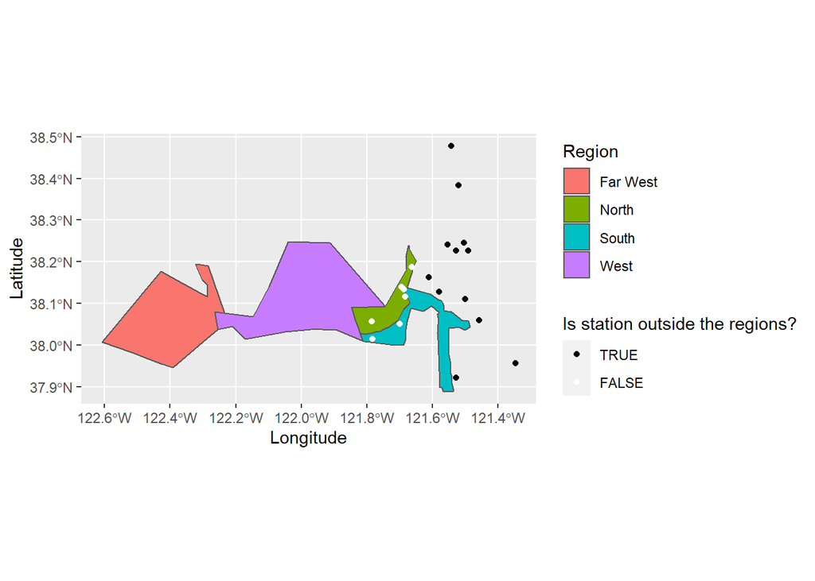

### Create annual data by region

- Same as above, but calculated for north and south region

Export annual station list to data/stations folder

```r
## Use DJFMP_Silverside_seine_annual_input so the stations saved here match those used
## in the annual and annual regional datasets saved above.
DJFMP_Silverside_seine_annual_input %>%
  select(Station, Latitude, Longitude) %>%
  distinct() %>%
  mutate(Survey="Delta Juvenile Fish Monitoring Program") %>%
  write.csv(file=file.path("data/stations/stations_fish_DJFMP_annual.csv"),
            row.names=FALSE)
```

## List of stations for monthly data

Show sampling effort since 1995 for stations

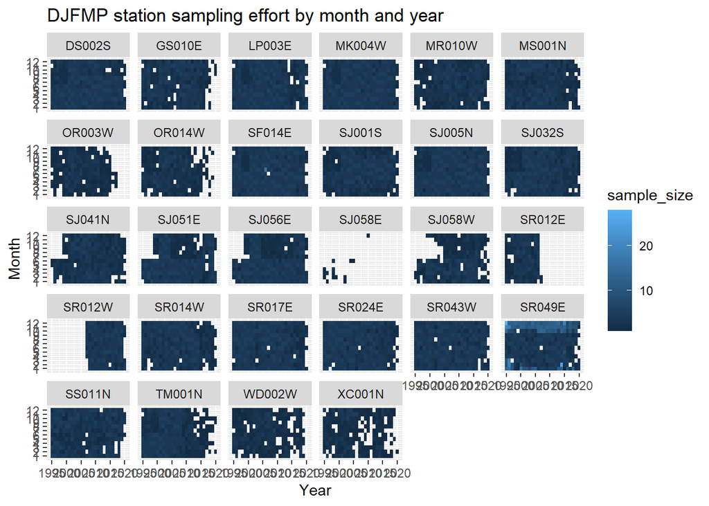

Combine SJ058E with SJ058W and SR012E with SR012W. All stations look somewhat usable.

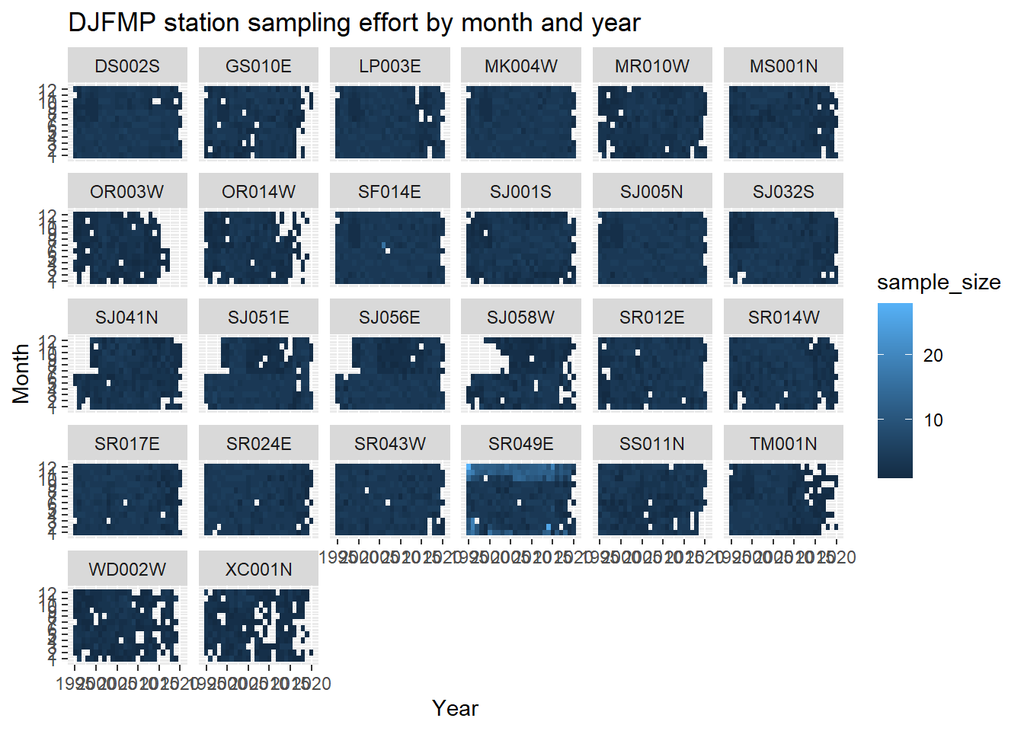

## Final data processing for monthly data

Added Largemouth Bass and aggregate Centrarchids metrics. Centrarchids include Bluegill, Redear Sunfish, Smallmouth and Largemouth Bass. Centrarchid length-weight conversion equations are taken from Sarah’s compiled equations here: https://portal.edirepository.org/nis/mapbrowse?packageid=edi.508.1

- Join SR012E and SR012W together, SJ058E and SJ058W
- Add length-weight conversion to get biomass
- Use all months, but from 1995 and on
- Filtered to region boundaries as defined by Denise
- Write csv to monthly averages folder
- Export stations to data_stations folder??

### Map export for monthly stations